# STA 207: Assignment I

(Your name and student ID)

**Instructions** You may adapt the code in the course materials or any sources (e.g., the Internet, classmates, friends). In fact, you can craft solutions for almost all questions from the course materials with minor modifications. However, you need to write up your own solutions and acknowledge all sources that you have cited in the Acknowledgement section.

Failing to acknowledge any non-original efforts will be counted as plagiarism. This incidence will be reported to the Student Judicial Affairs.

A consulting firm is investigating the relationship between wages and occupation. The file `Wage.csv` contains three columns, which are

- `wage`, the wage of the subject,
- `ethnicity`, the ethnicity of the subject,
- and `occupation`, the occupation of the subject.

We will only use `wage` and `occupation` in this assignment.

```r
Wage=read.csv('Wage.csv');
#library(gplots)
#attach(Wage)
```

```r
head(Wage)
```

```
##    wage ethnicity occupation
## 1  5.10  hispanic     worker
## 2  4.95      cauc     worker
## 3  6.67      cauc     worker
## 4  4.00      cauc     worker
## 5  7.50      cauc     worker
## 6 13.07      cauc     worker
```

1. Write down a one-way ANOVA model for this data. For consistency, choose the letters from $\{Y,\alpha, \mu, \epsilon\}$ and use the factor-effect form.

$$Y_{i,j}=\mu + \alpha_i+ \epsilon_{i,j}, \ j=1,\ldots, n_i, i =1,\ldots, 6$$
where $\{ \alpha_i\}$ satisfies that $\sum_{i=1}^6 n_i \alpha_i=0$ and $\{\epsilon_{i,j}\}$ are i.i.d. $N(0,\sigma^2)$.

In this model, $\alpha_i$ represent the effect from the six conditions, which are management ($i=1$), office ($i=2$), sales ($i=3$), services ($i=4$), technical ($i=5$), and worker ($i=6$). The outcome $Y_{i,j}$ represents the $j$th subject under $i$th condition. The mean effect $\mu$ represents the mean wage in the population. The errors $\epsilon_{i,j}$ capture any unexplained effects on wages Values of $n_i$ can be found in the following table.

```r
table(Wage$occupation)
```

```
##
## management     office      sales   services  technical     worker
##         55         97         38         83        105        156
```

2. Write down the least squares estimator of $\alpha_i$ for all $i$. Find the expectation and variance of this estimate in terms of $\{n_i\}$ and the parameters of the model.

$\mu=\sum_{i=1}^6 (n_i /n_T) \mu_i$ and $\alpha_i = \mu_i -\mu$

The least squares estimators are $\hat{\mu}=\sum_{i=1}^6 (n_i /n_T) \bar{Y}_{i\cdot}$ and $\hat{\alpha}_i = \bar{Y}_{i\cdot} -\hat{\mu}$.

$\mathbb{E}[{\hat{\alpha}_i}] = \mathbb{E}[ \bar{Y}_{i\cdot} -\hat{\mu}] = \mathbb{E}[ \bar{Y}_{i\cdot} -\sum_{i=1}^6 (n_i /n_T) \bar{Y}_{i\cdot}]$ by linearity this is equal to $\mathbb{E}[\bar{Y}_{i\cdot}] - \mathbb{E}[\sum_{i=1}^6 (n_i /n_T)\bar{Y}_{i\cdot}] = \mathbb{E}[\bar{Y}_{i\cdot}] - \sum_{i=1}^6 (n_i /n_T)\mathbb{E}[\bar{Y}_{i\cdot}] = {\mu_i} - \sum_{i=1}^6 (n_i /n_T){\mu_i}$

$\mathbb{var}(\hat{\alpha}_i)$ $= \mathbb{var}(\bar{Y_i} - \hat{\mu})$

$= \mathbb{var}(\bar{Y_i} - \sum_{k=1}^6 (n_k /n_T) \bar{Y_k})$

$=\mathbb{var}(\bar{Y_i} - (n_i /n_T) \bar{Y_i} - \sum_{k \neq i}^6 (n_k /n_T) \bar{Y_k})$

$= \mathbb{var}(\bar{Y_i}) * (1 - (n_k/n_T))^2 + \sum_{k \neq i}^6 (n_k /n_T)^2 \mathbb{var}(\bar{Y_k})$

$= (1- 2 (n_i/n_T)) * (\sigma^2 / n_T) + \sum_{k = i}^6 (n_k /n_T)^2 (\sigma^2 / n_T)$

```r
#find the mean wage for managment

aggregate(wage ~ occupation, data = Wage, mean)
```

```
##   occupation      wage
## 1 management 12.704000
## 2     office  7.422577
## 3      sales  7.592632
## 4   services  6.537470
## 5  technical 11.947429
## 6     worker  8.426474
```

3. Obtain the main effects plots. Summarize your findings.

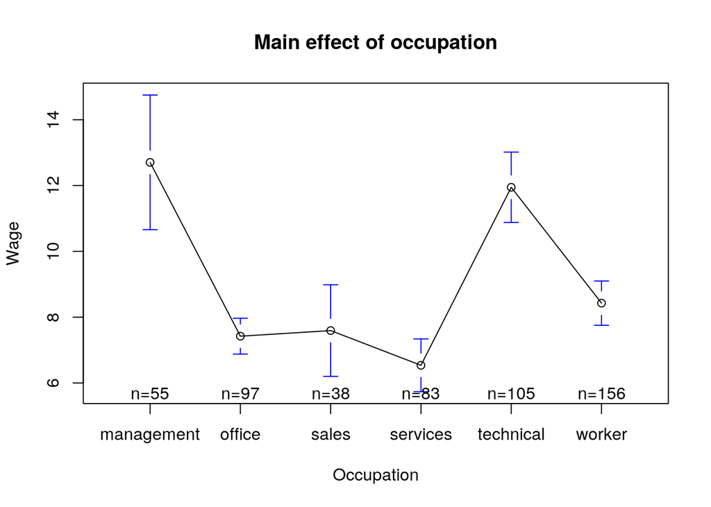

```r
library(gplots)
plotmeans(wage ~ occupation, data = Wage,
          xlab = "Occupation", ylab = "Wage",
          main="Main effect of occupation")
```

Observations:

- Differences across the occupations.
- Largest variablity in management.
- Services has the lowest wage.
- Different sample sizes under the occupation.
4. Set up the ANOVA table using `R` for your model. Briefly explain this table.

```r
aov.fit <- aov(wage ~ occupation, data = Wage)
summary(aov.fit)
```

```
##              Df Sum Sq Mean Sq F value Pr(>F)
## occupation    5   2538   507.5   23.22 <2e-16 ***
## Residuals   528  11539    21.9
## ---
## Signif. codes:  0 '***' 0.001 '**' 0.01 '*' 0.05 '.' 0.1 ' ' 1
```

Occupation sum of squares is 2538. Residual sum of squares is 11539. F-test statsistcs is 23.22. P-value is <2e-16.

5. Test whether there is any association between `occupation` and `wage`. In particular, you need to (a) define the null and alternative hypotheses using the notation in Part 1, (b) conduct the test, and (c) explain your test result.

P-value is <2e-16 which is less than 0.05 which indicates signifiant difference of weights under different conditions.

$$H_O: \alpha_1 = \alpha_2 = \alpha_3 = \alpha_4 = \alpha_5 = \alpha_6 = 0 \\ {\rm v.s.} \\ H_A: {\rm not \ all\ } \alpha_i\ {\rm are\ the\ zero}$$

6. For the model fitted in Part 4, carry out the necessary diagnostics to check if the model assumptions given in Part 1 are valid. What are your findings?

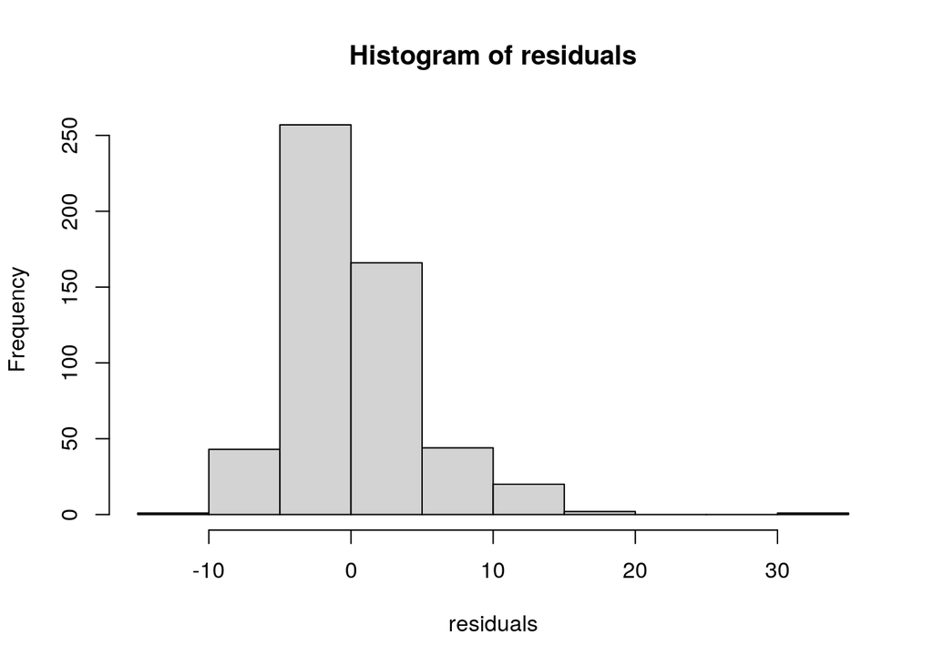

```r
# Obtain the residuals from the ANOVA fit
residuals=  aov.fit$residuals;
hist(residuals)
```

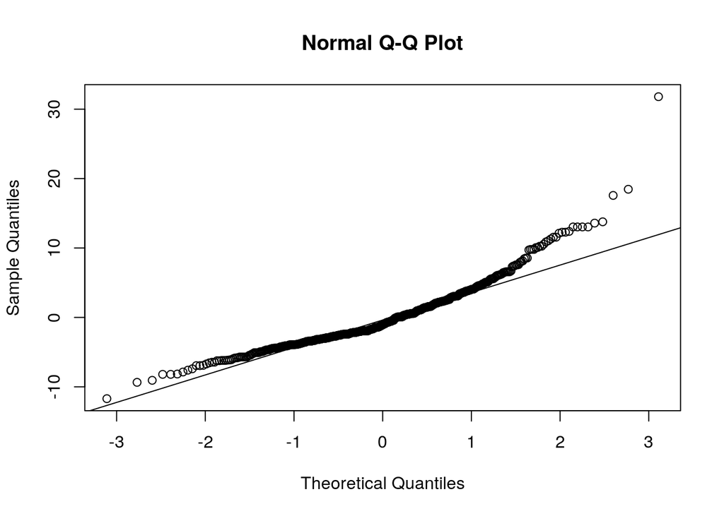

```r
# QQ plot
qqnorm(residuals);qqline(residuals)
```

This assumption that the errors are normal is not correct as the qq plot tells us that it is tailed.

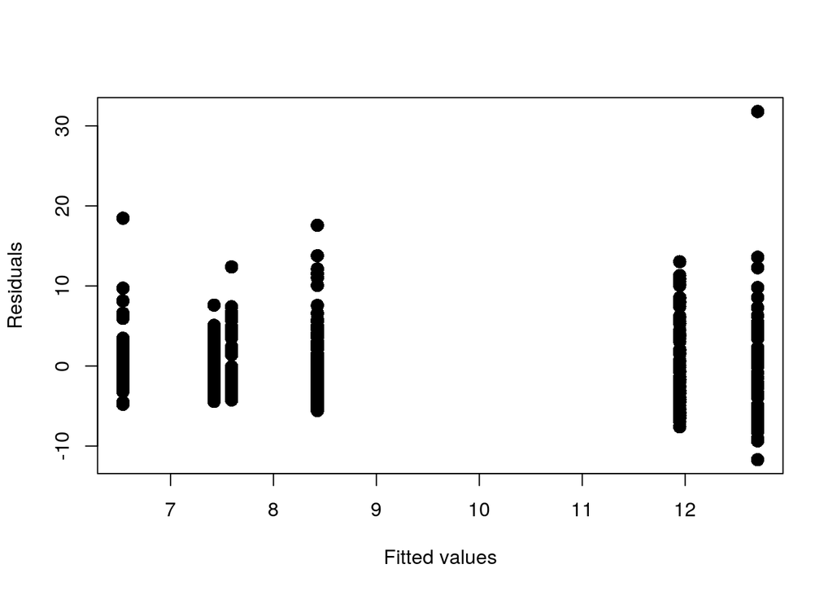

```r
plot(residuals~aov.fit$fitted.values,type='p',pch=16,cex=1.5,xlab="Fitted values",ylab="Residuals")
```

It looks like the variance of errors are unequal.

These plots are subject to interpetation by simply eyeing them. It seems that the farthest right set of data points has the most variation but we can use more quantitative methods.

Then null hypothesis is that all the variances are equal and the alternaive is that they are not all equal

$H_0: \sigma_1=\cdots =\sigma_6$ against the alternative $H_a:$ not all $\sigma$s are equal.

```r
# Calculate the variances for each group:
(vars = tapply(Wage$wage,Wage$occupation,var))
```

```
## management     office      sales   services  technical     worker
##  57.342947   7.284698  17.912123  13.492970  30.512735  18.068740
```

```r
alpha=0.05;
```

```r
ns=as.numeric(table(Wage$occupation)) #number of samples
ns
```

```
## [1]  55  97  38  83 105 156
```

```r
# Hartley test:
H.stat=max(vars)/min(vars);
H.stat
```

```
## [1] 7.871698
```

```r
#install.packages('SuppDists')
library(SuppDists) # The null distribution is in this package
# Both df and k only take integers:
qmaxFratio(1-alpha,df=floor(sum(ns)/length(ns)-1),k=length(ns))
```

```
## [1] 1.844871
```

```r
qmaxFratio(1-alpha,df=ceiling(sum(ns)/length(ns)-1),k=length(ns))
```

```
## [1] 1.844871
```

We can reject the null hypothesis at signinfiance level $\alpha = 0.05$ to conclude that there are unequal variances.

In short, we found the variances are not equal and the residuals are not normally distributed.

7. Assuming that the assumptions you made are true, can you statistically conclude if there is one occupation where the mean wage is the highest? Use the most appropriate method (use $\alpha=0.05$) to support your statement.

$$H_O:\ for\ every\ i,\ there\ exists\ j\ such\ that\ \mu_i \le \mu_j$$

$$H_A:there\ exists\ one\ i\ such\ that\ \mu_i > \mu_j\ for\ all\ i \neq\ j$$

```r
tk = TukeyHSD(aov.fit, conf.level = .95)
tk
```

```
##   Tukey multiple comparisons of means
##     95% family-wise confidence level
##
## Fit: aov(formula = wage ~ occupation, data = Wage)
##
## $occupation
##                            diff         lwr       upr     p adj
## office-management    -5.2814227 -7.53836588 -3.024479 0.0000000
## sales-management     -5.1113684 -7.93192217 -2.290815 0.0000046
## services-management  -6.1665301 -8.49132800 -3.841732 0.0000000
## technical-management -0.7565714 -2.98218646  1.469044 0.9265714
## worker-management    -4.2775256 -6.37435762 -2.180694 0.0000001
## sales-office          0.1700543 -2.38885725  2.728966 0.9999657
## services-office      -0.8851074 -2.88440478  1.114190 0.8032931
## technical-office      4.5248513  2.64180401  6.407898 0.0000000
## worker-office         1.0038970 -0.72503588  2.732830 0.5584749
## services-sales       -1.0551617 -3.67411581  1.563792 0.8589942
## technical-sales       4.3547970  1.82347368  6.886120 0.0000170
## worker-sales          0.8338428 -1.58502882  3.252714 0.9223496
## technical-services    5.4099587  3.44609529  7.373822 0.0000000
## worker-services       1.8890045  0.07238631  3.705623 0.0361288
## worker-technical     -3.5209542 -5.20878674 -1.833122 0.0000001
```

We notice that managment has the highest mean wage and managment and technical are not significanlty different from each other and hence there is no occupation with the greatest mean wage.

8. Consider a one-way ANOVA model with fixed effects
   $$\begin{equation}\label{eqn:anova}
   Y_{i,j}=\mu + \alpha_i+ \epsilon_{i,j}, \ j=1,\ldots, n_i, i =1,\ldots, r,
   \end{equation}$$
   where $\{ \alpha_i\}$ satisfies that $\sum_{i} n_i \alpha_i=0$ and $\{\epsilon_{i,j}\}$ are i.i.d. $N(0,\sigma^2)$. For the above model, write down the loss function associated with least squares, denoted as $L_1(\mu,\alpha)$, and write down the log-likelihood, denoted as $L_2(\mu,\alpha)$.

For the loss function we will just use the squared loss function learned in lecture 4 of STA 200B and minimize that

$argmin({ L_1(\mu,\alpha) = (\mu - \alpha)^2})$

Likelihood:
$$l_2(\mu,\alpha_1,..,\alpha_6,\sigma) = \prod_{i=1}^r \prod_{j=1}^{n_i} \frac{1}{\sqrt{2\pi \sigma^2} } \exp\left[-\frac{ (Y_{i,j} - \mu-\alpha_i)^2}{2\sigma^2}\right]$$
Log-likelihood:
$$L_2(\mu,\alpha_1,...,\alpha_6,\sigma) = \sum_{i=1}^r \sum_{j=1}^{n_i} \log\left\{ \frac{1}{\sqrt{2\pi \sigma^2} } \exp\left[-\frac{ (Y_{i,j} - \mu-\alpha_i)^2}{2\sigma^2} \right] \right\}$$

subject to the constraint that $\sum_{i} n_i \alpha_i=0$.

9. Find the maximum likelihood estimator of $\mu$ and $\alpha$ using the log-likelihood $L_2(\mu,\alpha)$ in Question 8.

The above simplifies to

$L_2(\mu,\alpha_1,...,\alpha_6,\sigma) = \sum_{i=1}^r i\log(\frac{1}{\sqrt{2\pi \sigma^2}}) + \sum_{i=1}^r \sum_{j = 1}^{n_i} -\frac{(Y_{i,j} - \mu - \alpha_i)^2}{2 \sigma^2}$

Now we can just optimize for $\mu$ and $\alpha$ and so we ignore the terms with $\sigma^2$ and hence we have

$argmin_{\mu, \alpha}\sum_{i=1}^r \sum_{j = 1}^{n_i} {(Y_{i,j} - \mu - \alpha_i)^2}$

subject to the constraint that $\sum_{i} n_i \alpha_i=0$.

## Acknowledgement

I utlized discussion notes, Piazza, office hours, lecture notes, and one note from STA 200B on everything